# Praca Domowa 1

Indywidualnie, zaimplementować model sieci neuronowej (MLP) do klasyfikacji w `torch` i przetestować go na dwóch zbiorach danych: XOR (wygenerować), oraz iris (pobrać). Powstały raport w formatach `.ipynb` oraz `.html` powinien zawierać wionski z przeprowadzonej analizy.

1. do 2 punktów uzyskuje się za skuteczność klasyfikacji modeli i wizualizację procesu uczenia
2. do 2 punktów uzyskuje się za analizę porównawczą różnych architektur sieci neuronowych (liczby neuronów i warstw)
3. 1 punkt uzyskuje się za analizę porównawczą różnych wartości `learning_rate`
4. 1 punkt uzyskuje się za wytrenowanie skutecznego modelu na zbiorze danych MNIST i analizę macierzy pomyłek tej klasyfikacji
5. 1 punkt uzyskuje się za ewaluowanie powyższych zjawisk na podzbiorze treningowym i testowym (analizę zjawiska przeuczenia)
6. 1 punkt uzyskuje się za animację zmiany granic decyzyjnych klasyfikacji podczas uczenia (na wybranym zbiorze danych)
7. do 2 punktów uzyskuje sie za jakość raportu (opisu, wizualizacji, kodu).

**Uwaga!** Warto zacząć od uczenia bardzo małych sieci i stopniowo zwiększać ich skomplikowanie.

Deadline: 16 marca 23:59. Na zajęciach 17 marca 5 wybranch osób krótko zaprezentuje swoje wyniki.

```python
import numpy as np
import torch
import seaborn as sns
import matplotlib.pyplot as plt
import pandas as pd
```

```python
from sklearn.preprocessing import StandardScaler
from sklearn.model_selection import train_test_split
```

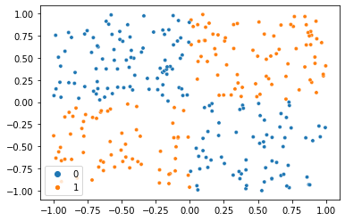

```python
n = 300
train_data_xor = np.random.uniform(low=-1, high=1, size=(n,2))
train_target_xor = np.where(
    (((train_data_xor[:, 0] > 0) & (train_data_xor[:, 1] > 0)) | ((train_data_xor[:, 0] < 0) & (train_data_xor[:, 1] < 0))),
    1,0)
sns.scatterplot(
    x = train_data_xor[:, 0],
    y = train_data_xor[:, 1],
    size = 1,
    hue=train_target_xor
)
plt.show()
```

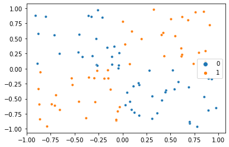

```python
n =100
test_data_xor = np.random.uniform(low=-1, high=1, size=(n,2))
test_target_xor = np.where(
    (((test_data_xor[:, 0] > 0) & (test_data_xor[:, 1] > 0)) | ((test_data_xor[:, 0] < 0) & (test_data_xor[:, 1] < 0))),
    1,0)
sns.scatterplot(
    x = test_data_xor[:, 0],
    y = test_data_xor[:, 1],
    size = 1,
    hue=test_target_xor
)
```

```python
scaler = StandardScaler()
```

```python
train_data_xor = scaler.fit_transform(train_data_xor)
test_data_xor = scaler.transform(test_data_xor)
train_data_xor = torch.FloatTensor(train_data_xor)
test_data_xor = torch.FloatTensor(test_data_xor)
train_target_xor = torch.LongTensor(train_target_xor)
test_target_xor = torch.LongTensor(test_target_xor)
```

class 0: Iris Setosa class 1: Iris Versicolor class 2: Iris Virginica

```python
data_iris = pd.read_csv('iris.csv')
```

```python
data_iris
```

|  | sepal_length | sepal_width | petal_length | petal_width | species |
| --- | --- | --- | --- | --- | --- |
| 0 | 5.1 | 3.5 | 1.4 | 0.2 | setosa |
| 1 | 4.9 | 3.0 | 1.4 | 0.2 | setosa |
| 2 | 4.7 | 3.2 | 1.3 | 0.2 | setosa |
| 3 | 4.6 | 3.1 | 1.5 | 0.2 | setosa |
| 4 | 5.0 | 3.6 | 1.4 | 0.2 | setosa |
| ... | ... | ... | ... | ... | ... |
| 145 | 6.7 | 3.0 | 5.2 | 2.3 | virginica |
| 146 | 6.3 | 2.5 | 5.0 | 1.9 | virginica |
| 147 | 6.5 | 3.0 | 5.2 | 2.0 | virginica |
| 148 | 6.2 | 3.4 | 5.4 | 2.3 | virginica |
| 149 | 5.9 | 3.0 | 5.1 | 1.8 | virginica |

150 rows × 5 columns

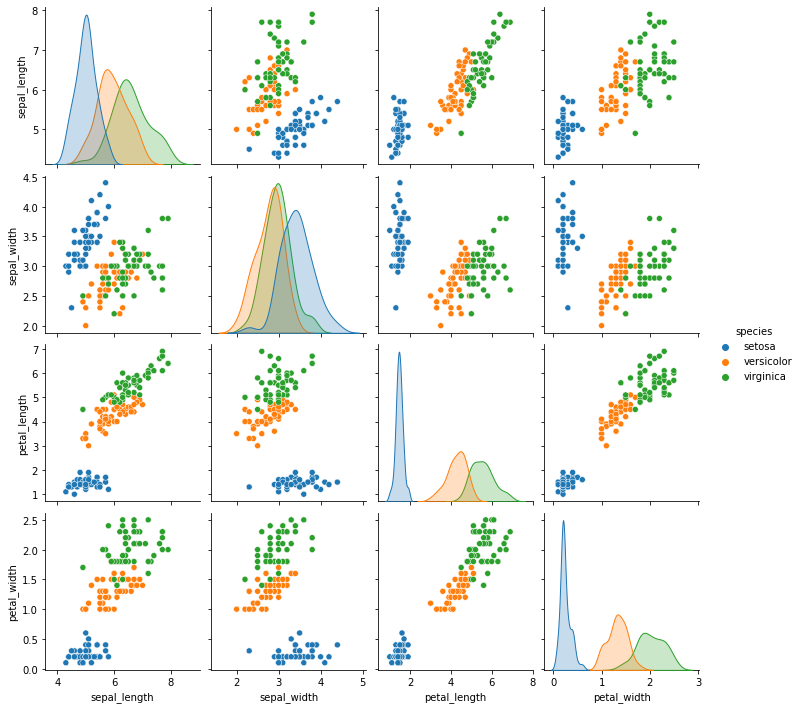

```python
sns.pairplot( data=data_iris, vars=('sepal_length','sepal_width','petal_length','petal_width'), hue='species' )
```

```python
data_iris['species'] = data_iris['species'].map({'setosa':0,'versicolor':1,'virginica':2})
```

```python
data_iris.head()
```

|  | sepal_length | sepal_width | petal_length | petal_width | species |
| --- | --- | --- | --- | --- | --- |
| 0 | 5.1 | 3.5 | 1.4 | 0.2 | 0 |
| 1 | 4.9 | 3.0 | 1.4 | 0.2 | 0 |
| 2 | 4.7 | 3.2 | 1.3 | 0.2 | 0 |
| 3 | 4.6 | 3.1 | 1.5 | 0.2 | 0 |
| 4 | 5.0 | 3.6 | 1.4 | 0.2 | 0 |

```python
X = data_iris.drop(["species"],axis=1).values
y = data_iris["species"].values
```

```python
X_train, X_test, y_train, y_test = train_test_split(X, y, test_size=0.30, random_state=42)
```

```python
X_train = scaler.fit_transform(X_train)
X_test = scaler.transform(X_test)
```

```python
X_train = torch.FloatTensor(X_train)
X_test = torch.FloatTensor(X_test)
y_train = torch.LongTensor(y_train)
y_test = torch.LongTensor(y_test)
```

```python
import torch.nn as nn
```

```python
# Sequential ze wykonywane są te komendy wypisane po przecinku po kolei
# Flatten splaszcza do dwoch wymiarow
# Linear stosujemy transformacje liniową Linear(in_features, out_features)
# in_features - size of each input sample
# ReLU - ReLU(x) = max(0, x)
net = torch.nn.Sequential(
    torch.nn.Flatten(),
    torch.nn.Linear(4, 3),
    torch.nn.ReLU(),
    torch.nn.Linear(3, 3)
)

def init_weights(m):
    # czy m jest typu torch.nn.Linear
    if isinstance(m, torch.nn.Linear):
        # dane w m.weights nadpisujemy przez rozklad normalny N(mean, std^2)
        torch.nn.init.normal_(m.weight, std=0.01)

net.apply(init_weights)
```

```
Sequential(
  (0): Flatten(start_dim=1, end_dim=-1)
  (1): Linear(in_features=4, out_features=3, bias=True)
  (2): ReLU()
  (3): Linear(in_features=3, out_features=3, bias=True)
)
```

```python
learning_rate = 0.05
# CrossEntropyLoss mowi jaka jest szansa ze hipoteza jest prawdziwa
#  Jest to funkcja dzięki, dzięki której wiemy czy model jest dobry czy zły, na jej podstawie dokonujemy optymalizacji. Informuje ona o ilości popełnianych błędów przez nasz model, jeżeli wartość jest wysoka to znaczy, że nasz model wymaga jeszcze uczenia, czyli dostosowania wag z macierzy
loss = torch.nn.CrossEntropyLoss(reduction='none')
optimizer = torch.optim.SGD(net.parameters(), lr=learning_rate) # Stochastic Gradient Descent
```

```python
import random


def data_iter(batch_size, features, labels):
    num_examples = len(features)
    indices = list(range(num_examples))
    # The examples are read at random, in no particular order
    random.shuffle(indices)
    for i in range(0, num_examples, batch_size):
        batch_indices = torch.tensor(
            indices[i: min(i + batch_size, num_examples)])
        yield features[batch_indices], labels[batch_indices]
```

```python
import tqdm
# pip install tqdm
```

```python
#for epoch in tqdm.tqdm(range(num_iter)):
def training(hidden_dim, learning_rate, batch_size, X_test, y_test, X_train, y_train, num_iter):

    errors_train = []
    errors_test = []
    losses = []

    net = torch.nn.Sequential(
        torch.nn.Flatten(),
        torch.nn.Linear(4, hidden_dim),
        torch.nn.ReLU(),
        torch.nn.Linear(hidden_dim, 3)
    )

    net.apply(init_weights)
    loss = torch.nn.CrossEntropyLoss(reduction='none')
    optimizer = torch.optim.SGD(net.parameters(), lr=learning_rate) # Stochastic Gradient Descent

    for epoch in range(num_iter):
        losses_iter = []
        errors_train_iter = []
        errors_test_iter = []

        for X, y in data_iter(batch_size, X_test, y_test):
            y_hat = net(X) #model
            errors_test_iter += [(y != y_hat.argmax(1)).float().mean().item()]

        for X, y in data_iter(batch_size, X_train, y_train):
            y_hat = net(X)
            errors_train_iter += [(y != y_hat.argmax(1)).float().mean().item()]
            l = loss(y_hat, y)
            optimizer.zero_grad()
            l.mean().backward()
            losses_iter += [l.mean().item()]
            optimizer.step()

        errors_train += [np.mean(errors_train_iter)]
        errors_test += [np.mean(errors_test_iter)]
        losses += [np.mean(losses_iter)]
    return errors_train, errors_test, losses
```

```python
import matplotlib.pyplot as plt
def plot(hidden_dim, learning_rate, batch_size, X_test, y_test, X_train, y_train, num_iter):
    errors_train, errors_test, losses = training( hidden_dim,  learning_rate, batch_size, X_test, y_test, X_train, y_train, num_iter)
    plt.figure(figsize=(12, 8))
    plt.plot(range(num_iter), errors_train)
    plt.plot(range(num_iter), errors_test)
    plt.plot(range(num_iter), losses)
    plt.title("Learning curves")
    plt.legend(['Error_train', 'Error_test', 'Loss'])
    plt.show()
```

## Batches

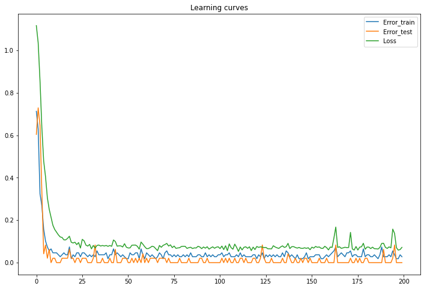

```python
plot(4, 0.1, 4, X_test, y_test, X_train, y_train, 200)
```

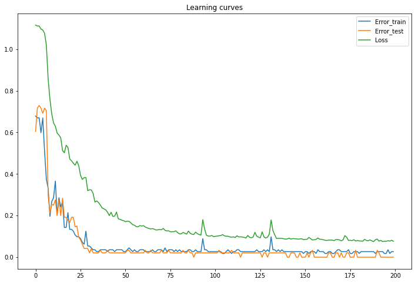

```python
plot(4, 0.1, 8, X_test, y_test, X_train, y_train, 200)
```

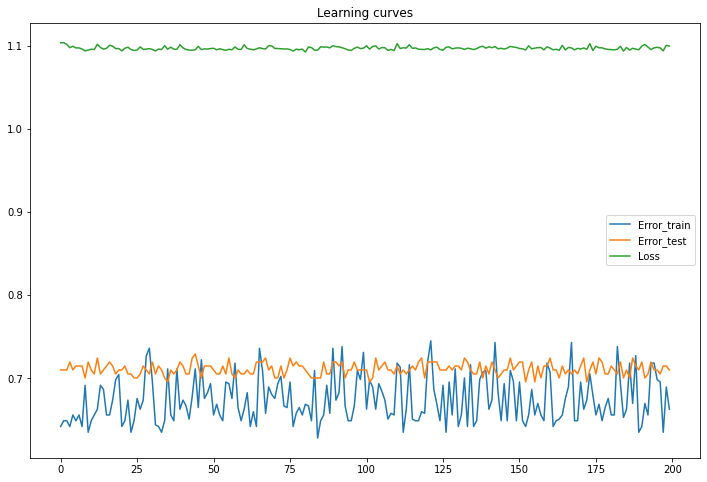

```python
plot(4, 0.1, 16, X_test, y_test, X_train, y_train, 200)
```

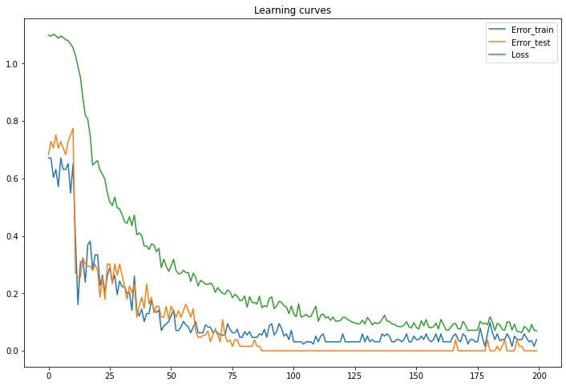

```python
plot(4, 0.1, 32, X_test, y_test, X_train, y_train, 200)
```

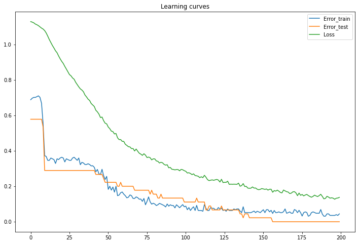

```python
plot(4, 0.1, 64, X_test, y_test, X_train, y_train, 200)
```

## Learning rate

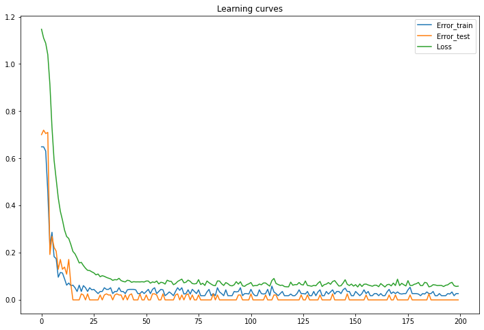

```python
plot(4, 0.2, 16, X_test, y_test, X_train, y_train, 200)
```

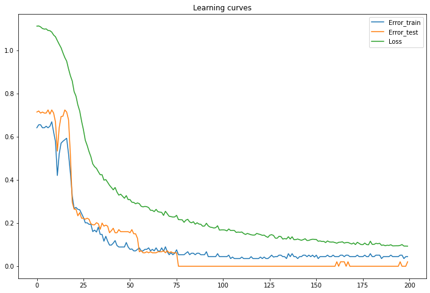

```python
plot(4, 0.05, 16, X_test, y_test, X_train, y_train, 200)
```

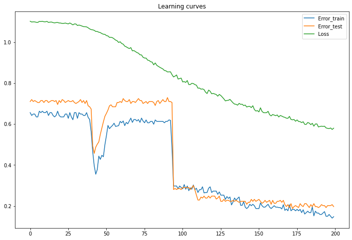

```python
plot(4, 0.01, 16, X_test, y_test, X_train, y_train, 200)
```

Współczynnik uczenia odpowada za tempo uczenia się algorytmu. Mniejsza wartość współczynnika skutkuje dłuższym czasem treningowym, natomiast zbyt duży wartość może spowodować zbyt szybkie uczenie nieoptymalnego zestawu wag lub niestabilnym procesem treningowym.

## Epoch

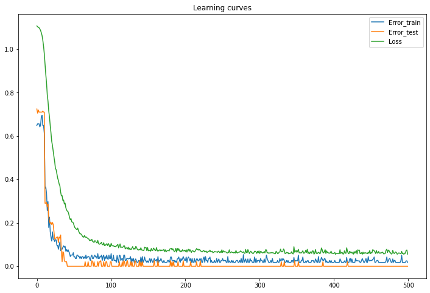

```python
plot(4, 0.1, 16, X_test, y_test, X_train, y_train, 500)
```

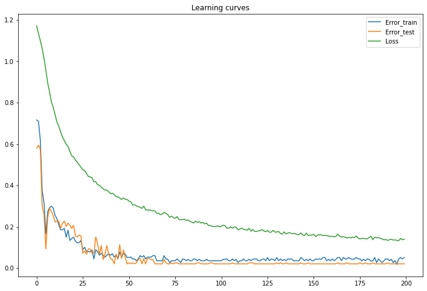

```python
plot(4, 0.1, 16, X_test, y_test, X_train, y_train, 200)
```

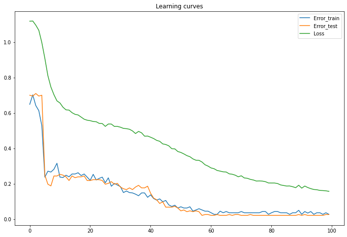

```python
plot(4, 0.1, 16, X_test, y_test, X_train, y_train, 100)
```

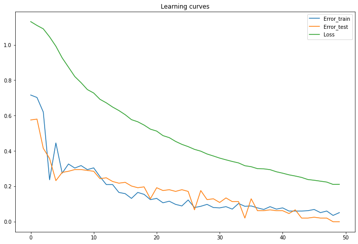

```python
plot(4, 0.1, 16, X_test, y_test, X_train, y_train, 50)
```

Powyżej przedstawione są wykresy dla różnych ilości iteracji algorytmu trenującego Z kolejnymi iteracjami wartości błędów spadają. Zbyt duża liczba iteracji moze skutkować prztrenowaniem,który co prawda dobrze uczy sie danych, jednak nie uogólnia się na nowe dane.

## Number of hidden neurons

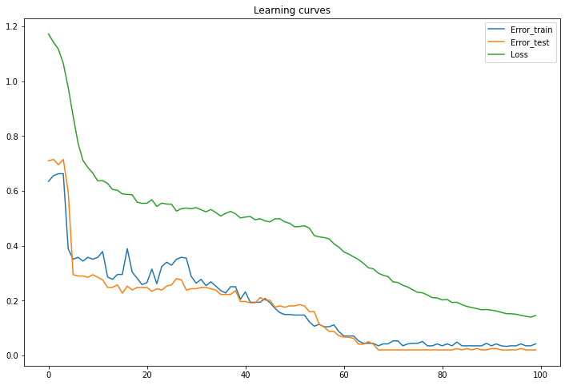

```python
plot(2, 0.1, 16, X_test, y_test, X_train, y_train, 100)
```

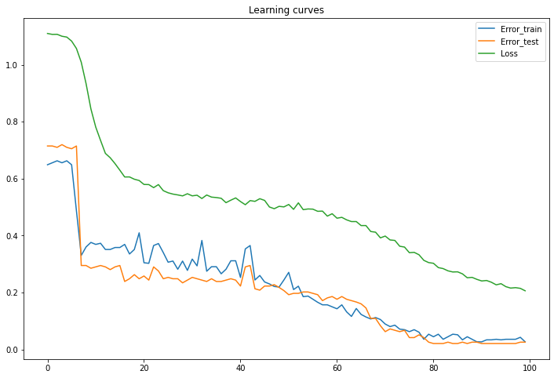

```python
plot(3, 0.1, 16, X_test, y_test, X_train, y_train, 100)
```

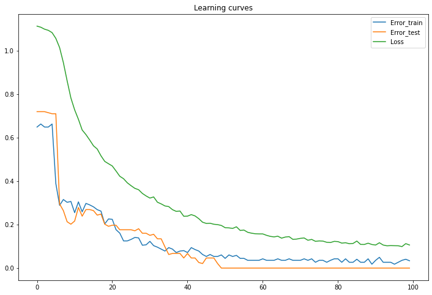

```python
plot(4, 0.1, 16, X_test, y_test, X_train, y_train, 100)
```

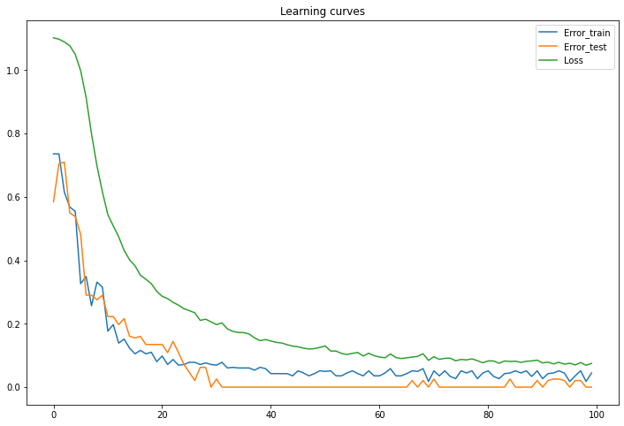

```python
plot(10, 0.1, 16, X_test, y_test, X_train, y_train, 100)
```

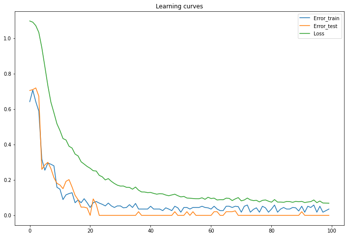

```python
plot(50, 0.1, 16, X_test, y_test, X_train, y_train, 100)
```

```python
net1 = torch.nn.Sequential(
    torch.nn.Flatten(),
    torch.nn.Linear(4, 3),
    torch.nn.ReLU(),
    torch.nn.Linear(3, 3),
    torch.nn.ReLU(),
    torch.nn.Linear(3, 3)
)
```

```python
net4 = torch.nn.Sequential(
    torch.nn.Flatten(),
    torch.nn.Linear(4, 30),
    torch.nn.ReLU(),
    torch.nn.Linear(30, 10),
    torch.nn.ReLU(),
    torch.nn.Linear(10, 3)
)
```

```python
net2 = torch.nn.Sequential(
    torch.nn.Flatten(),
    torch.nn.Linear(4, 3),
    torch.nn.ReLU(),
    torch.nn.Linear(3, 3),
    torch.nn.ReLU(),
    torch.nn.Linear(3, 3),
    torch.nn.ReLU(),
    torch.nn.Linear(3, 3)
)
```

```python
net3 = torch.nn.Sequential(
    torch.nn.Flatten(),
    torch.nn.Linear(4, 50),
    torch.nn.ReLU(),
    torch.nn.Linear(50, 25),
    torch.nn.ReLU(),
    torch.nn.Linear(25, 9),
    torch.nn.ReLU(),
    torch.nn.Linear(9, 3)
)
```

```python
#for epoch in tqdm.tqdm(range(num_iter)):
def training_net(net, learning_rate, batch_size, X_test, y_test, X_train, y_train, num_iter):

    errors_train = []
    errors_test = []
    losses = []



    net.apply(init_weights)
    loss = torch.nn.CrossEntropyLoss(reduction='none')
    optimizer = torch.optim.SGD(net.parameters(), lr=learning_rate) # Stochastic Gradient Descent

    for epoch in range(num_iter):
        losses_iter = []
        errors_train_iter = []
        errors_test_iter = []

        for X, y in data_iter(batch_size, X_test, y_test):
            y_hat = net(X) #model
            errors_test_iter += [(y != y_hat.argmax(1)).float().mean().item()]

        for X, y in data_iter(batch_size, X_train, y_train):
            y_hat = net(X)
            errors_train_iter += [(y != y_hat.argmax(1)).float().mean().item()]
            l = loss(y_hat, y)
            optimizer.zero_grad()
            l.mean().backward()
            losses_iter += [l.mean().item()]
            optimizer.step()

        errors_train += [np.mean(errors_train_iter)]
        errors_test += [np.mean(errors_test_iter)]
        losses += [np.mean(losses_iter)]
    return errors_train, errors_test, losses
```

```python
def plot_net(net, learning_rate, batch_size, X_test, y_test, X_train, y_train, num_iter):
    errors_train, errors_test, losses = training_net( net,  learning_rate, batch_size, X_test, y_test, X_train, y_train, num_iter)
    plt.figure(figsize=(12, 8))
    plt.plot(range(num_iter), errors_train)
    plt.plot(range(num_iter), errors_test)
    plt.plot(range(num_iter), losses)
    plt.title("Learning curves")
    plt.legend(['Error_train', 'Error_test', 'Loss'])
    plt.show()
```

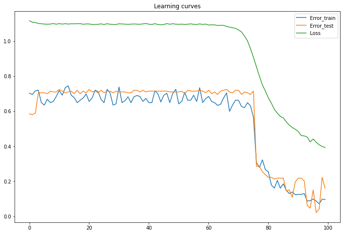

```python
plot_net(net1, 0.1, 16, X_test, y_test, X_train, y_train, 100)
```

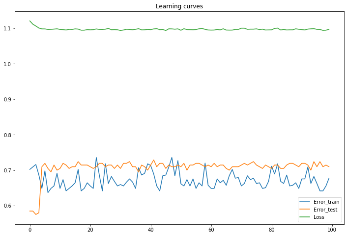

```python
plot_net(net2, 0.1, 16, X_test, y_test, X_train, y_train, 100)
```

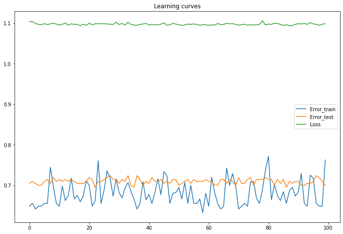

```python
plot_net(net3, 0.1, 16, X_test, y_test, X_train, y_train, 100)
```

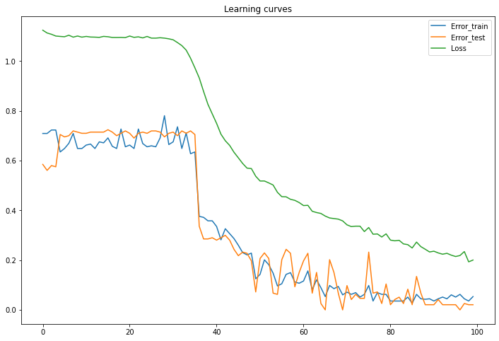

```python
plot_net(net4, 0.1, 16, X_test, y_test, X_train, y_train, 100)
```

```python
net_a= torch.nn.Sequential(
    torch.nn.Flatten(),
    torch.nn.Linear(4, 3),
    torch.nn.Sigmoid(),
    torch.nn.Linear(3, 3)
)
```

```python
net_b= torch.nn.Sequential(
    torch.nn.Flatten(),
    torch.nn.Linear(4, 3),
    torch.nn.Sigmoid(),
    torch.nn.Linear(3, 3),
    torch.nn.Sigmoid(),
    torch.nn.Linear(3, 3)
)
```

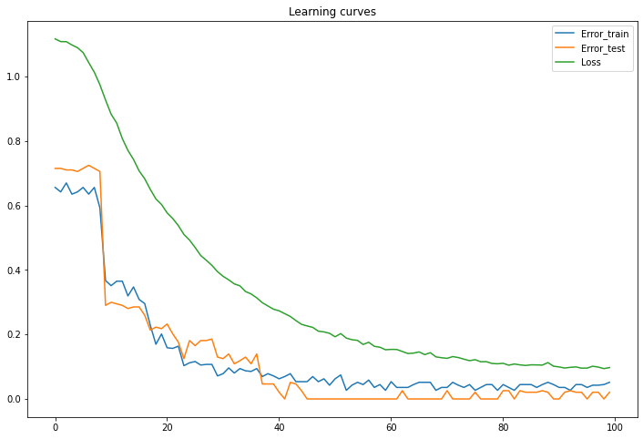

```python
plot(3, 0.1, 16, X_test, y_test, X_train, y_train, 100)
```

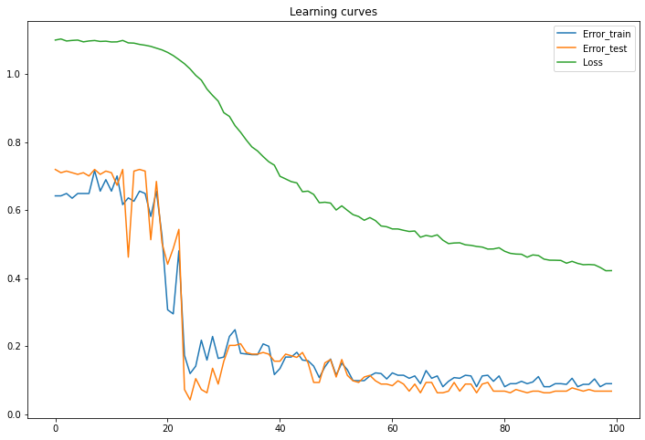

```python
plot_net(net_a, 0.1, 16, X_test, y_test, X_train, y_train, 100)
```

Porównanie funkcji aktywacyjnych - ReLU i Sigmoid ReLU(x) = max(x, 0) Sigmoid(x) = 1/(1 + exp(-x))

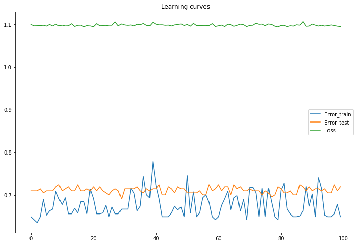

```python
plot_net(net_b, 0.1, 16, X_test, y_test, X_train, y_train, 100)
```

Na algorytm trenujący wpływają takie wartości jak learning rate, liczba neuronów, warstw, czy iteracji.

```python
from matplotlib import animation, rc
from IPython.display import HTML
```

```python
# pip install torchvision
import torchvision
import torch
import numpy as np
```

```python
mnist_train = torchvision.datasets.MNIST(
    root="/Users/zuzannaglinka/2022L-WB-XIC/labs/lab2/data", train=True, transform=torchvision.transforms.ToTensor(), download=True
)
mnist_test = torchvision.datasets.MNIST(
    root="/Users/zuzannaglinka/2022L-WB-XIC/labs/lab2/data", train=False, transform=torchvision.transforms.ToTensor(), download=True
)
```

```python
mnist_train[0][0]
```

[output not shown]

[output cut: 57 more lines]

[output not shown]

```python
examplary_dataloader_train = torch.utils.data.DataLoader(mnist_train, batch_size=1)
X, y = next(iter(examplary_dataloader_train))
{'image': X, 'class': y}
```

[output not shown]

[output cut: 58 more lines]

[output not shown]

```python
net = torch.nn.Sequential(
    torch.nn.Flatten(),
    torch.nn.Linear(784, 64), # 28^2
    torch.nn.ReLU(),
    torch.nn.Linear(64, 10)
)

def init_weights(m):
    if isinstance(m, torch.nn.Linear):
        torch.nn.init.normal_(m.weight, std=0.01)

net.apply(init_weights)
```

```
Sequential(
  (0): Flatten(start_dim=1, end_dim=-1)
  (1): Linear(in_features=784, out_features=64, bias=True)
  (2): ReLU()
  (3): Linear(in_features=64, out_features=10, bias=True)
)
```

```python
learning_rate = 0.05
loss = torch.nn.CrossEntropyLoss(reduction='none')
optimizer = torch.optim.SGD(net.parameters(), lr=learning_rate)  # Stochastic Gradient Descent
```

```python
num_iter = 10
batch_size = 256
dataloader_train = torch.utils.data.DataLoader(mnist_train, batch_size, shuffle=True, num_workers=2)
dataloader_test = torch.utils.data.DataLoader(mnist_test, batch_size, shuffle=True, num_workers=2)

losses = []
errors_train = []
errors_test = []
```

```python
for epoch in range(num_iter):
    losses_iter = []
    errors_train_iter = []
    errors_test_iter = []

    for X, y in dataloader_test:
        y_hat = net(X)
        errors_test_iter += [(y != y_hat.argmax(1)).float().mean().item()]

    for X, y in dataloader_train:
        y_hat = net(X)
        errors_train_iter += [(y != y_hat.argmax(1)).float().mean().item()]
        l = loss(y_hat, y)
        optimizer.zero_grad()
        l.mean().backward()
        losses_iter += [l.mean().item()]
        optimizer.step()

    errors_train += [np.mean(errors_train_iter)]
    errors_test += [np.mean(errors_test_iter)]
    losses += [np.mean(losses_iter)]
```

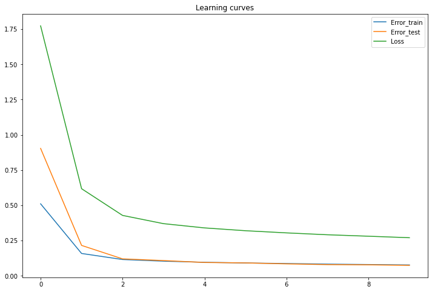

```python
import matplotlib.pyplot as plt
plt.figure(figsize=(12, 8))
plt.plot(range(num_iter), errors_train)
plt.plot(range(num_iter), errors_test)
plt.plot(range(num_iter), losses)
plt.title("Learning curves")
plt.legend(['Error_train', 'Error_test', 'Loss'])
plt.show()
```

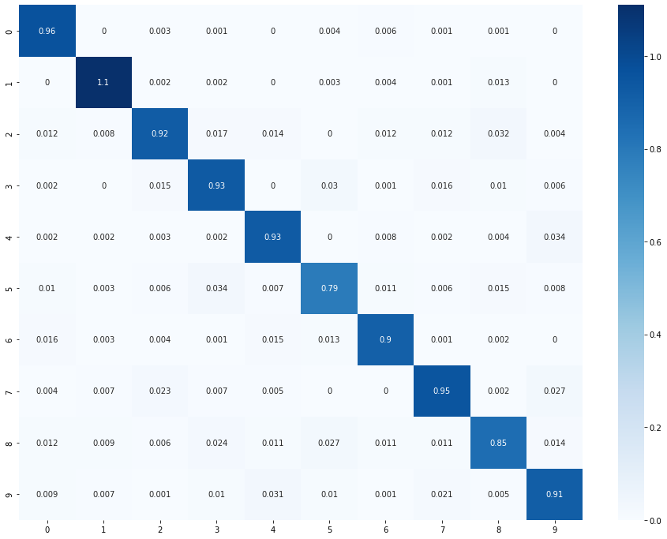

```python
from sklearn.metrics import confusion_matrix
import seaborn as sn
import pandas as pd

y_pred = []
y_true = []

# iterate over test data
for inputs, labels in dataloader_test:
    output = net(inputs) # Feed Network

    output = (torch.max(torch.exp(output), 1)[1]).data.cpu().numpy()
    y_pred.extend(output) # Save Prediction

    labels = labels.data.cpu().numpy()
    y_true.extend(labels) # Save Truth

# constant for classes
classes = ('0', '1', '2', '3', '4',
           '5', '6', '7', '8', '9')

# Build confusion matrix
cf_matrix = confusion_matrix(y_true, y_pred)
df_cm = pd.DataFrame(cf_matrix/np.sum(cf_matrix) *10, index = [i for i in classes],
                     columns = [i for i in classes])
plt.figure(figsize = (16, 12))
sn.heatmap(df_cm, annot=True, cmap="Blues")
plt.show()
```

```python
net5 = torch.nn.Sequential(
    torch.nn.Flatten(),
    torch.nn.Linear(2, 2),
    torch.nn.ReLU(),
    torch.nn.Linear(2, 2)
)
```

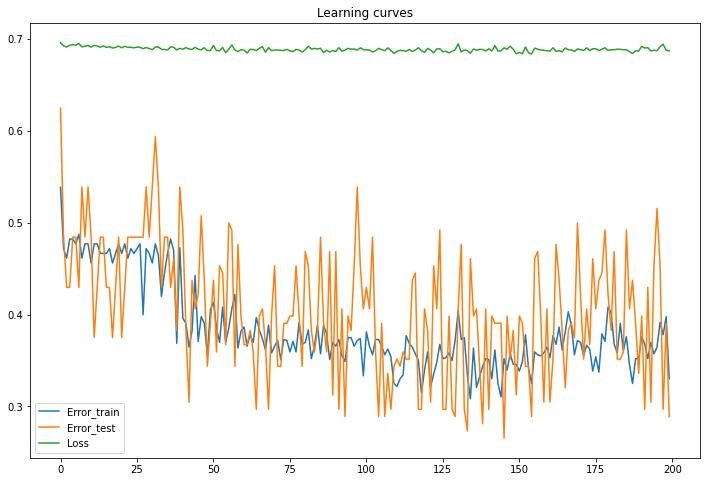

```python
plot_net(net5, 0.1, 32, test_data_xor, test_target_xor, train_data_xor, train_target_xor, 200)
```

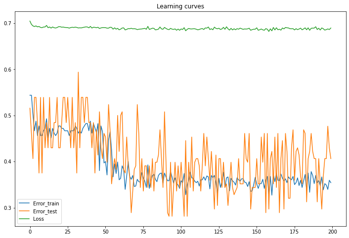

```python
plot_net(net5, 0.05, 32, test_data_xor, test_target_xor, train_data_xor, train_target_xor, 200)
```

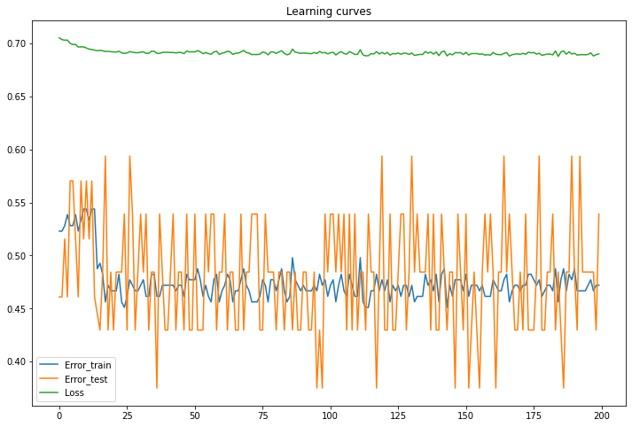

```python
plot_net(net5, 0.01, 32, test_data_xor, test_target_xor, train_data_xor, train_target_xor, 200)
```

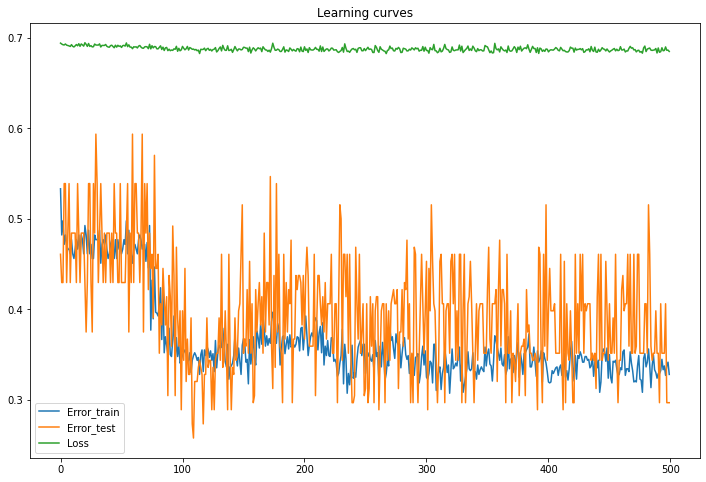

```python
plot_net(net5, 0.05, 32, test_data_xor, test_target_xor, train_data_xor, train_target_xor, 500)
```

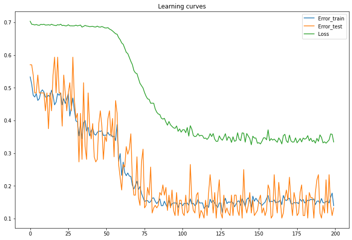

```python
plot_net(net5, 0.1, 32, test_data_xor, test_target_xor, train_data_xor, train_target_xor, 200)
```

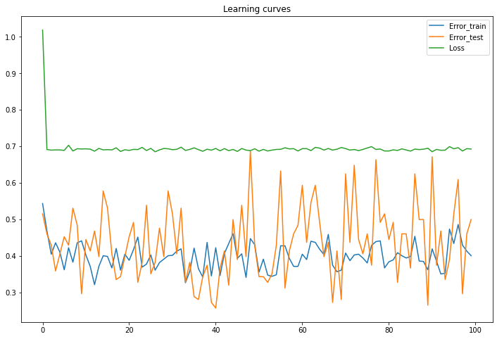

```python
plot_net(net5, 0.1, 32, test_data_xor, test_target_xor, train_data_xor, train_target_xor, 100)
```

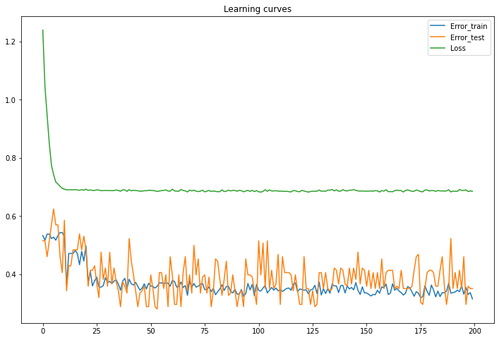

```python
plot_net(net5, 0.01, 32, test_data_xor, test_target_xor, train_data_xor, train_target_xor, 200)
```

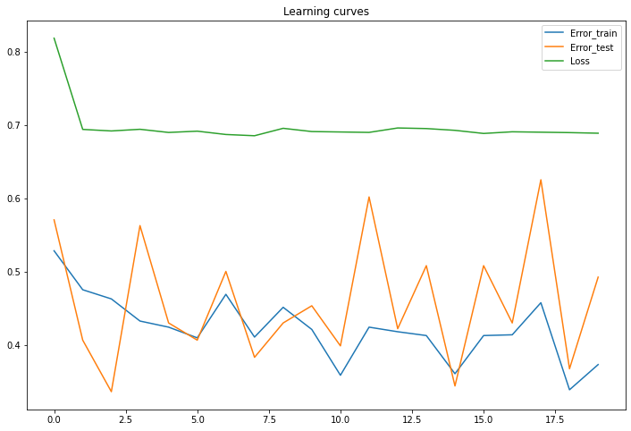

```python
plot_net(net5, 0.1, 32, test_data_xor, test_target_xor, train_data_xor, train_target_xor, 20)
```

```python
net6 = torch.nn.Sequential(
    torch.nn.Flatten(),
    torch.nn.Linear(2, 2),
    torch.nn.ReLU(),
    torch.nn.Linear(2, 2),
    torch.nn.ReLU(),
    torch.nn.Linear(2, 2)
)
```

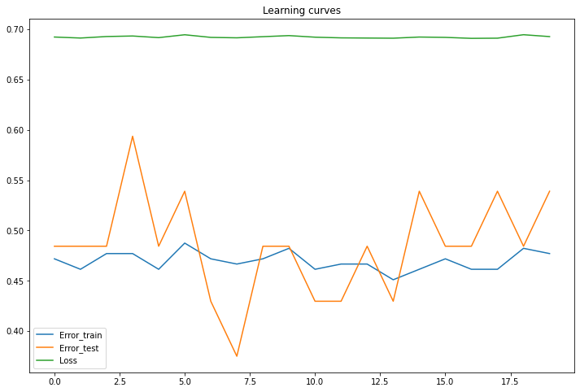

```python
plot_net(net6, 0.1, 32, test_data_xor, test_target_xor, train_data_xor, train_target_xor, 20)
```

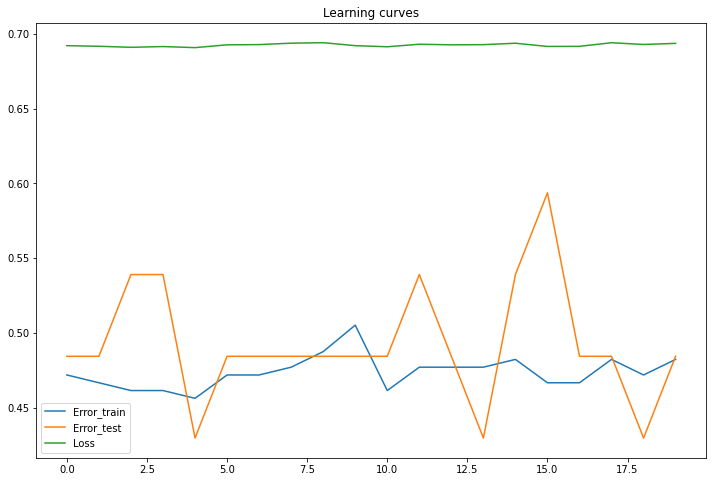

```python
net7 = torch.nn.Sequential(
    torch.nn.Flatten(),
    torch.nn.Linear(2, 2),
    torch.nn.ReLU(),
    torch.nn.Linear(2, 2),
    torch.nn.ReLU(),
    torch.nn.Linear(2, 2),
    torch.nn.ReLU(),
    torch.nn.Linear(2, 2)
)
plot_net(net6, 0.1, 32, test_data_xor, test_target_xor, train_data_xor, train_target_xor, 20)
```

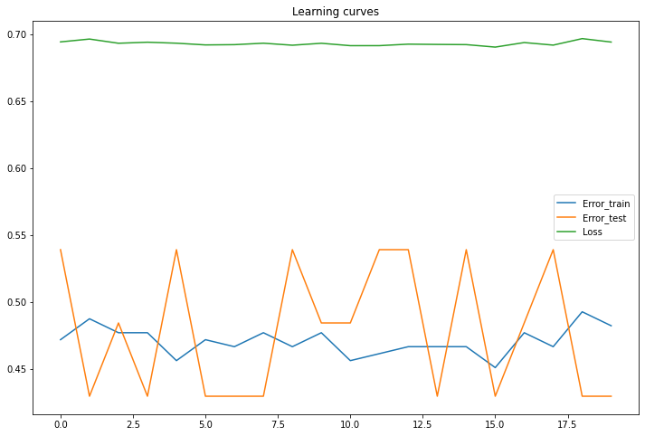

```python
net8 = torch.nn.Sequential(
    torch.nn.Flatten(),
    torch.nn.Linear(2, 2),
    torch.nn.Sigmoid(),
    torch.nn.Linear(2, 2)
)
plot_net(net8, 0.1, 32, test_data_xor, test_target_xor, train_data_xor, train_target_xor, 20)
```